**Introduction**

The data comprises combined student performance in Math course and Portuguese language course in secondary education of two Portuguese schools. This also is inclusive of their alcohol consumption rate during weekdays and weekends. This thus include both high and low consumption use.

**Load data**

```r
alc <- read.table("http://s3.amazonaws.com/assets.datacamp.com/production/course_2218/datasets/alc.txt", sep=",", header=TRUE)

# Accesss necessary library
library(dplyr)
```

```r
library(ggplot2)
# Column names
colnames(alc)
```

```
##  [1] "school"     "sex"        "age"        "address"    "famsize"
##  [6] "Pstatus"    "Medu"       "Fedu"       "Mjob"       "Fjob"
## [11] "reason"     "nursery"    "internet"   "guardian"   "traveltime"
## [16] "studytime"  "failures"   "schoolsup"  "famsup"     "paid"
## [21] "activities" "higher"     "romantic"   "famrel"     "freetime"
## [26] "goout"      "Dalc"       "Walc"       "health"     "absences"
## [31] "G1"         "G2"         "G3"         "alc_use"    "high_use"
```

```r
# glimpse at the alc data
glimpse(alc)
```

```
## Rows: 382
## Columns: 35
## $ school     <fct> GP, GP, GP, GP, GP, GP, GP, GP, GP, GP, GP, GP, GP,...
## $ sex        <fct> F, F, F, F, F, M, M, F, M, M, F, F, M, M, M, F, F, ...
## $ age        <int> 18, 17, 15, 15, 16, 16, 16, 17, 15, 15, 15, 15, 15,...
## $ address    <fct> U, U, U, U, U, U, U, U, U, U, U, U, U, U, U, U, U, ...
## $ famsize    <fct> GT3, GT3, LE3, GT3, GT3, LE3, LE3, GT3, LE3, GT3, G...
## $ Pstatus    <fct> A, T, T, T, T, T, T, A, A, T, T, T, T, T, A, T, T, ...
## $ Medu       <int> 4, 1, 1, 4, 3, 4, 2, 4, 3, 3, 4, 2, 4, 4, 2, 4, 4, ...
## $ Fedu       <int> 4, 1, 1, 2, 3, 3, 2, 4, 2, 4, 4, 1, 4, 3, 2, 4, 4, ...
## $ Mjob       <fct> at_home, at_home, at_home, health, other, services,...
## $ Fjob       <fct> teacher, other, other, services, other, other, othe...
## $ reason     <fct> course, course, other, home, home, reputation, home...
## $ nursery    <fct> yes, no, yes, yes, yes, yes, yes, yes, yes, yes, ye...
## $ internet   <fct> no, yes, yes, yes, no, yes, yes, no, yes, yes, yes,...
```

[output cut: 22 more lines]

**Explore relationships between high/low alcohol consumption**

To study the relationships between high/low alcohol consumption we select 4 variable that may relate with supported hypothesis. The variable of interest is high_use. we can check whether there is relationship between sex, absences, past failures and parents relationship status with alcohol use

Some assumptions

1 Sex: The males drink more than females

2. Failures : To much drinking might affect your study time and this affect the performance. Those whose past failures exceed 3 drink more
3. Absences: This can be brought about by hangovers after a heavy alcohol consumption
4. Parents relationship status : Those whose parents are apart drink more than those whose parents are together

**Exploring the relationship between the variables and alcohol consumption**

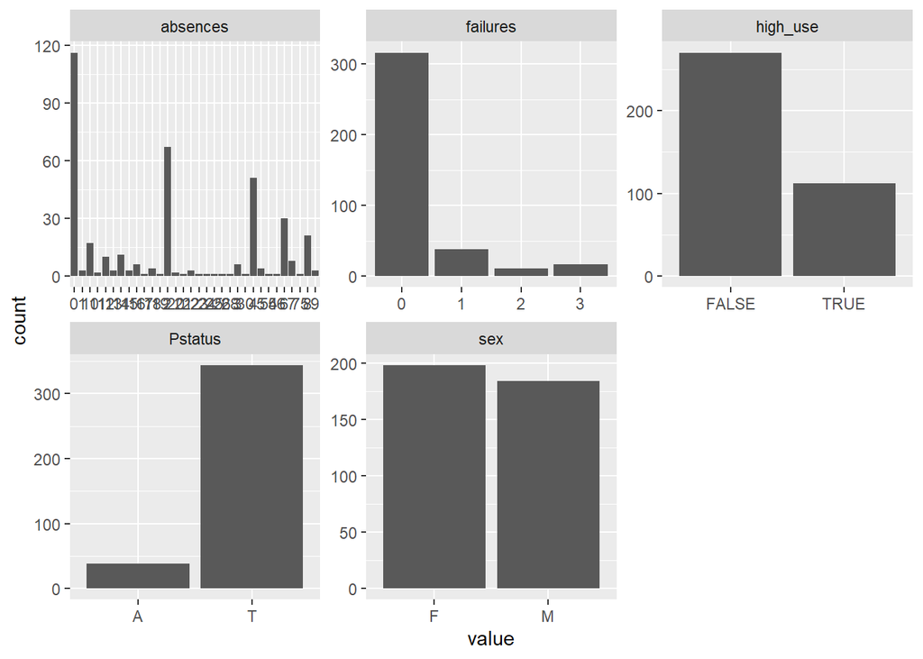

```r
# Load necessary libraries
library(ggplot2)
library(tidyr)
# Select the four variables
data<- alc %>%  select(sex, absences, Pstatus, failures, high_use)
gather(data) %>% ggplot(aes(value)) + facet_wrap("key", scales = "free") + geom_bar()
```

Assess relationships between and variable and alcohol consumption

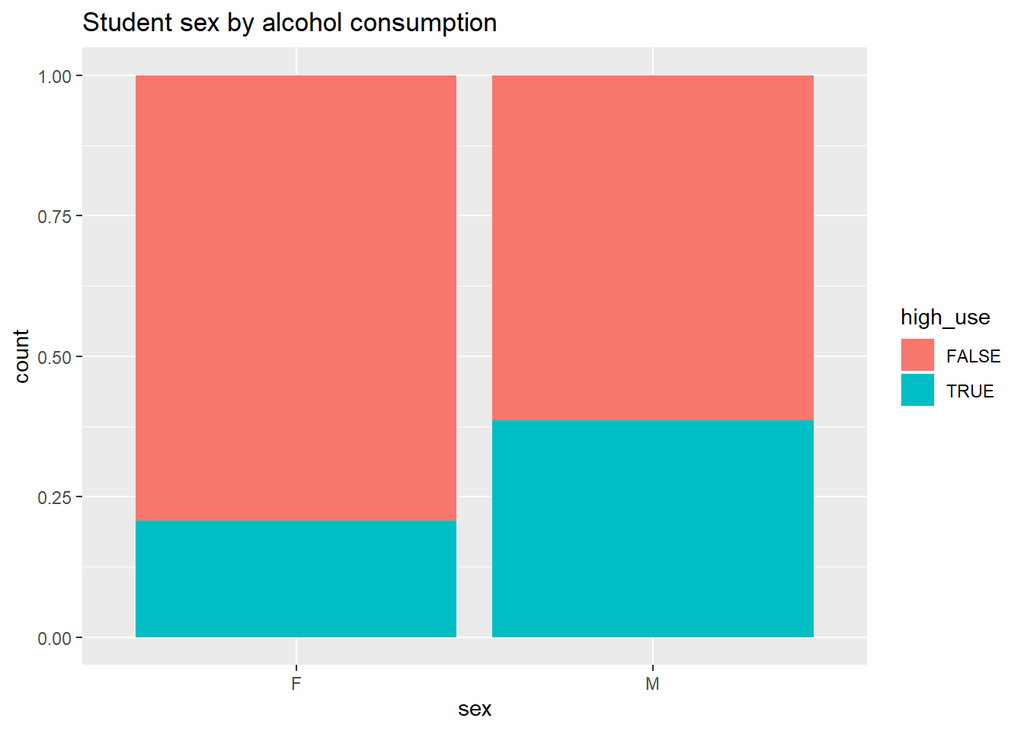

```r
#Exploring relationship of sex  with alcohol consumption
ggplot(data, aes(x=sex, fill=high_use)) + geom_bar(position="fill")  + ggtitle("Student sex by alcohol consumption")
```

Compared to females, the percentage of males that have high use of alcohol is higher

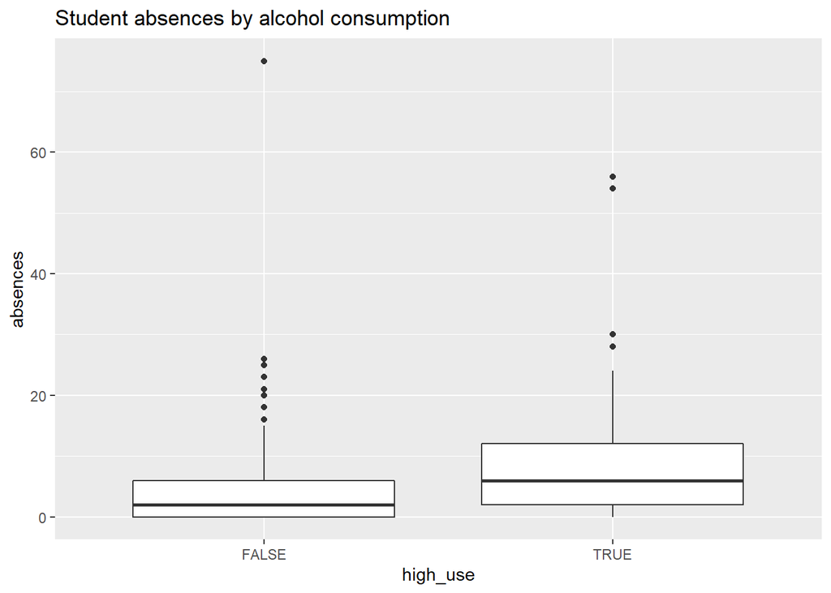

```r
# Exploring relationship of absences  with alcohol consumption using boxplot
g1 <- ggplot(alc, aes(x = high_use, y = absences))

# define the plot as a boxplot and draw it
g1 + geom_boxplot() + ylab("absences") + ggtitle("Student absences by alcohol consumption")
```

High alcohol use has an influences on the number of school absences

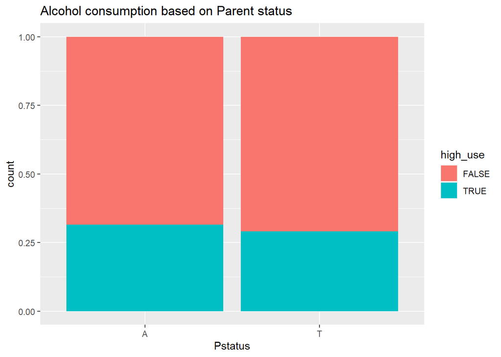

```r
# Exploring relationship between parent status and alcohol consumption
ggplot(data, aes(x=Pstatus, fill=high_use)) + geom_bar(position="fill")  + ggtitle("Alcohol consumption based on Parent status")
```

Seems parents status has no influence on high alcohol use

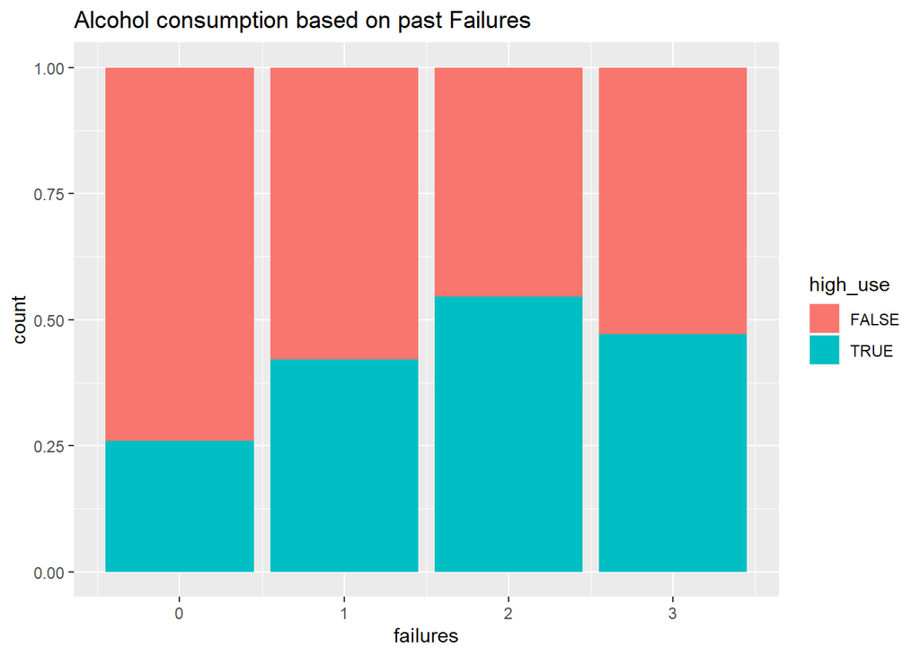

```r
# Exploring relationship between past failure and alcohol consumption
ggplot(data, aes(x=failures, fill=high_use)) + geom_bar(position="fill")  + ggtitle("Alcohol consumption based on past Failures")
```